# Exploratory Data Analysis of Prosper Loan Data by Rajesh Nair

Prosper is a unique concept of peer-to-peer lending where the Lenders and Borrowers are enrolled members.

The Borrowers list loan requests and Lenders invest in these listings requested by borrowers. Multiple Lenders can invest in a single listing. The Borrowers have Credit Grades associated with them which are AA, A, B, C, D, E and HR with AA being the best and HR being the worst. This gives Lenders an idea of the risk proportion of their investment.

The following fields names were replaced by removing the spaces and Brackets with Underscore for easy reference of these fields in the R

Original field names: ProsperRating (numeric), ProsperRating (Alpha), ListingCategory (numeric), TradesNeverDelinquent (percentage)

Updated field names: ProsperRating_numeric, ProsperRating_Alpha, ListingCategory_numeric, TradesNeverDelinquent_percentage

# Univariate Plots Section

```
## [1] 113937     81
```

```
##
##          AK    AL    AR    AZ    CA    CO    CT    DC    DE    FL    GA
##     0   200  1679   855  1901 14717  2210  1627   382   300  6720  5008
##    HI    IA    ID    IL    IN    KS    KY    LA    MA    MD    ME    MI
##   409   186   599  5921  2078  1062   983   954  2242  2821   101  3593
##    MN    MO    MS    MT    NC    ND    NE    NH    NJ    NM    NV    NY
##  2318  2615   787   330  3084    52   674   551  3097   472  1090  6729
##    OH    OK    OR    PA    RI    SC    SD    TN    TX    UT    VA    VT
##  4197   971  1817  2972   435  1122   189  1737  6842   877  3278   207
##    WA    WI    WV    WY
##  3048  1842   391   150
```

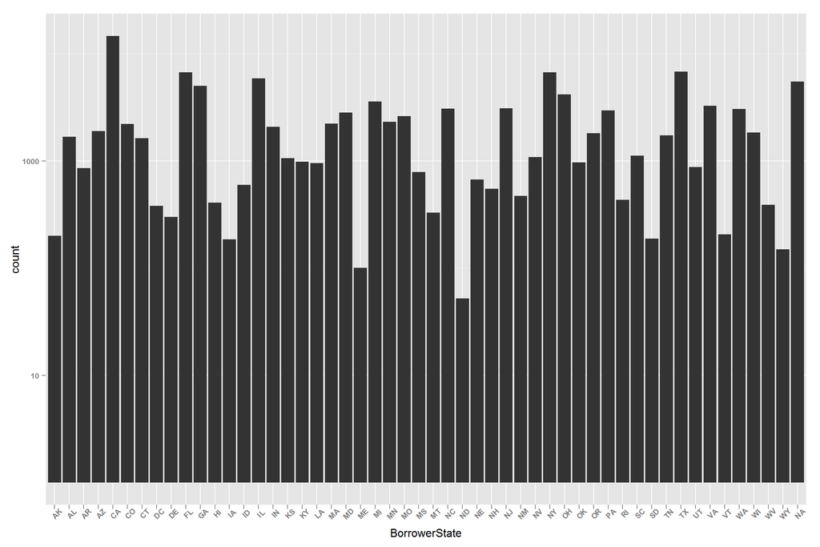

The Prosper Loan Data has 113937 Loan Records and there are 81 attributes for each record

The Histogram on Borrower State shows that California has most number of Borrowers

We have log transformed the Y axis because the maximum is few orders of magnitude greater than the minimum values

```
## [1] 14717    81
```

The Dataset derived for the state of California has 14717 Loan Records. Around 1/10th (14717 Cases) of the Prosper loans are from CA. Hence we would focus our analysis on the state of CA to analyze and understand various aspects of Prosper loan

In the data it is observed that the Home Ownership is indicated by attribute IsBorroweHomeowner. In order to use it in Plots we will derive a new variable called HomeOwnership with Values “OwnHome” and “RentedHome”

For the closed loans the Credit Grade is available in the “CreditGrade” column and for the Current loans the Credit Grade is available in “ProsperRating_Alpha” column. In order to do analysis on this variable we need to combine these 2 columns and hence we have derived a new column “CreditGrade_Derived”

There are many Occupations in the dataset. In order to form our understanding around this attribute we would group the related occupations so that we have only a handful of distinct values to concentrate on which in turn will help us understand the data better. The name of the new column derived will be “Occupation_Derived”

Based on my understanding from reading through the Prosper Website and by analyzing the Prosper Loan Dataset, the features which we would be considering for our exploratory analysis are as below:  
ClosedDate - If there is a date in this field then the Loan is Closed else it is Open  
CreditGrade_Derived - This is the new field derived for the Credit Grade for open and closed loans  
HomeOwnership - This field is derived from IsBorrowerHomeowner field. If it has value True the Borrower has Own Home else he is staying in Rented home  
Occupation_Derived - This field is derived from Occupation by grouping similar Occupations under one head  
Term - Tenure for which the Loan has been taken  
LoanStatus - The current Status of the Loan  
BorrowerRate - Rate of Interest at which the current Loan was Provided  
LenderYield - The Annual Return on Investment for the Lender  
BorrowerState - The State where the Borrower Resides. For our analysis we are focussing on the State of California  
Occupation - The Occupation of the Borrower  
EmploymentStatus - The Status of Employment of the Borrower  
TradesNeverDelinquent_percentage - Percentage of Trades which was never Deliquent  
DebtToIncomeRatio - The Ratio of Total Debt to Total Income of the Borrower  
IncomeRange - The Bucket in which the Borrower’s Income belongs  
StatedMonthlyIncome - The Borrower’s Monthly Income  
LoanOriginalAmount - The Loan amount provided to the Borrower  
LP_GrossPrincipalLoss - The non-recovery of the Principal due to Defaulted / Charged off Loans. This is applicable only to Closed Loans

```
##   AA    A    B    C    D    E   HR   NC NA's
## 1287 2382 2613 2956 2405 1793 1249   14   18
```

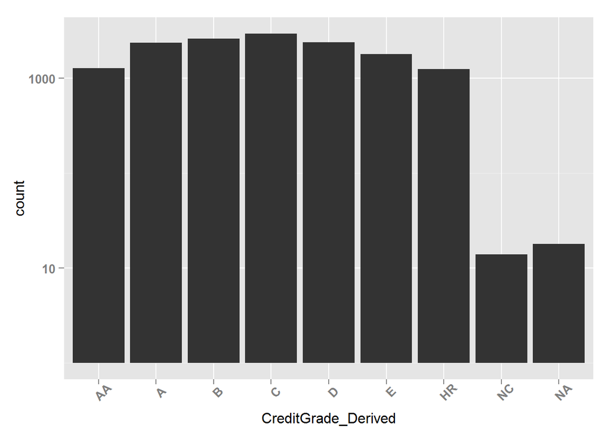

Credit Grades Range from AA to HR, AA being the Best rating and HR being the least rating. There are 18 records which don’t have any Rating and 14 records with Rating as NC which doesn’t seem to be a Valid rating as it is not appearing in the Prosper website

We have log transformed the Y axis because the maximum is few orders of magnitude greater than the minimum values

We see that the Distribution is a normal distribution with Less number of borrowers in AA and HR Category and maximum borrowers in the C Category. This is quite intuitive as there would be lesser number of population having highest rating of AA and hence the number of people applying for loan in this category will be less as compared to the other categories. The risk is highest for people having HR rating and there might be large number of loan applications getting rejected. Hence the population for the HR category is less

```
##  Not displayed   Not employed             $0      $1-24,999 $25,000-49,999
##            719            119            103            850           3398
## $50,000-74,999 $75,000-99,999      $100,000+
##           3947           2577           3004
```

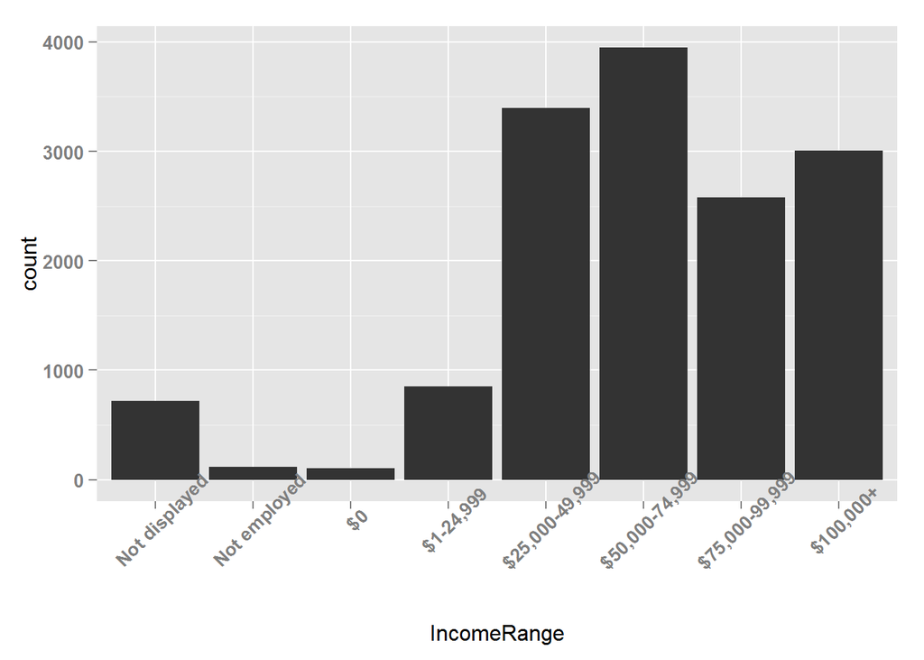

As expected the lower Income groups comprising Not Employed, $0 and $1-24,999 are lower in number as the loan application for most of them might not be getting accepted. There are a few cases for whom the Income is not displayed. They might be for people who do not want their income to be revealed to the Public

```
##    Min. 1st Qu.  Median    Mean 3rd Qu.    Max.
##   12.00   36.00   36.00   40.07   36.00   60.00
```

```
##
##    12    36    60
##   278 11666  2773
```

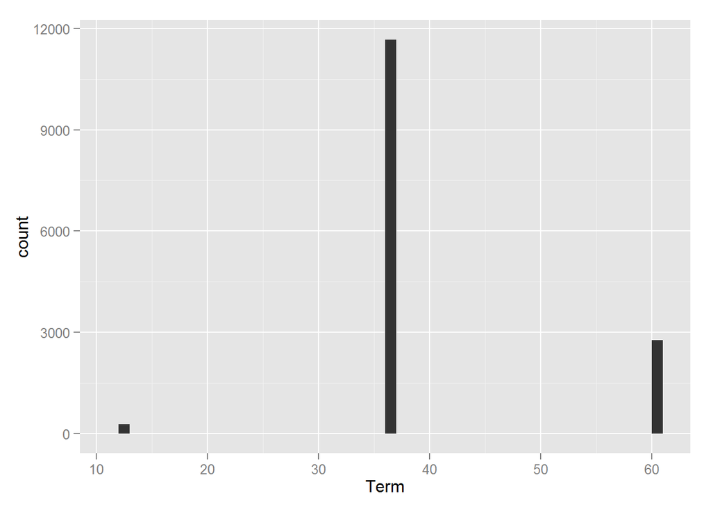

There are only 3 possible values which the Term takes 12, 36 and 60. Most Loans have the Term as 36. Then comes the Term 60 and there are only a few cases with term 12

```
##              Cancelled             Chargedoff              Completed
##                      0                   1574                   4957
##                Current              Defaulted FinalPaymentInProgress
##                   7209                    732                     38
##   Past Due (>120 days)   Past Due (1-15 days)  Past Due (16-30 days)
##                      0                     84                     20
##  Past Due (31-60 days)  Past Due (61-90 days) Past Due (91-120 days)
##                     43                     33                     27
```

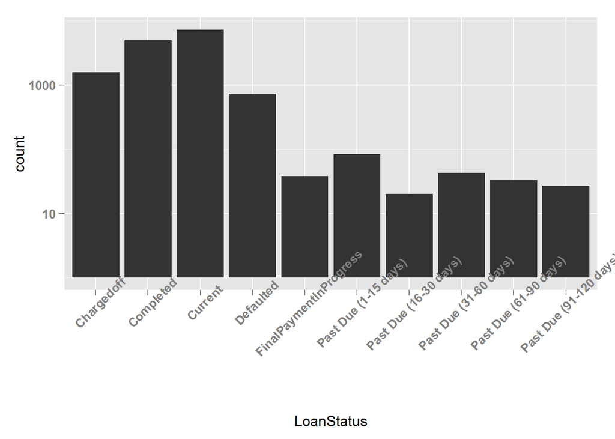

We have log transformed the Y axis because the maximum is few orders of magnitude greater than the minimum values

Most of the Loans are in Current Status. Almost 50% of the total Loans data available is in Current Status. A good percentage of Loans around 10% of the total loans has been Charged off. Around 5% of the total Loans have been Defaulted

```
##    Min. 1st Qu.  Median    Mean 3rd Qu.    Max.
##  0.0000  0.1314  0.1829  0.1923  0.2511  0.3600
```

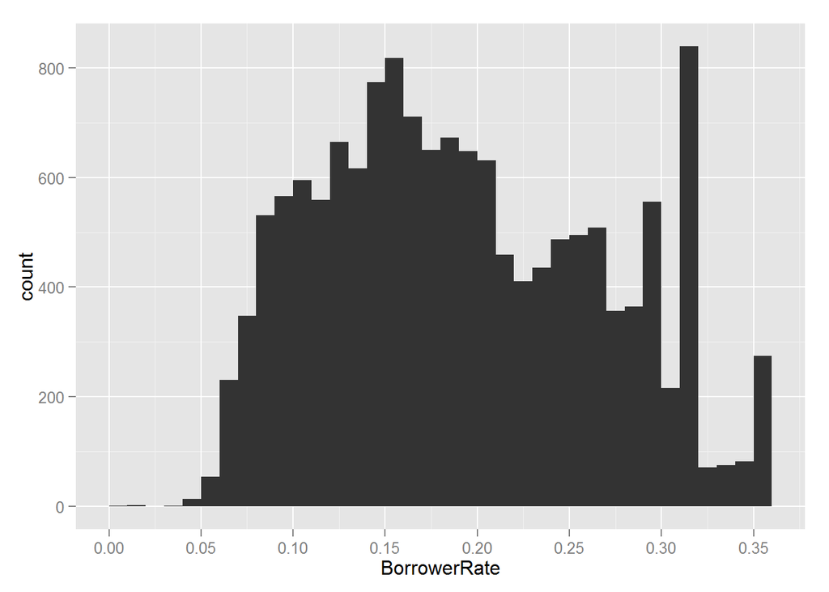

The distribution is approximately a normal distribution with lesser cases near the tails. There are a few cases near the 0 rate which might be an outlier. There are a few peaks near 0.3 which shows that a category of people might be getting loan at a very high rate as compared to the rest

```
##    Min. 1st Qu.  Median    Mean 3rd Qu.    Max.
## -0.0100  0.1214  0.1724  0.1821  0.2411  0.3400
```

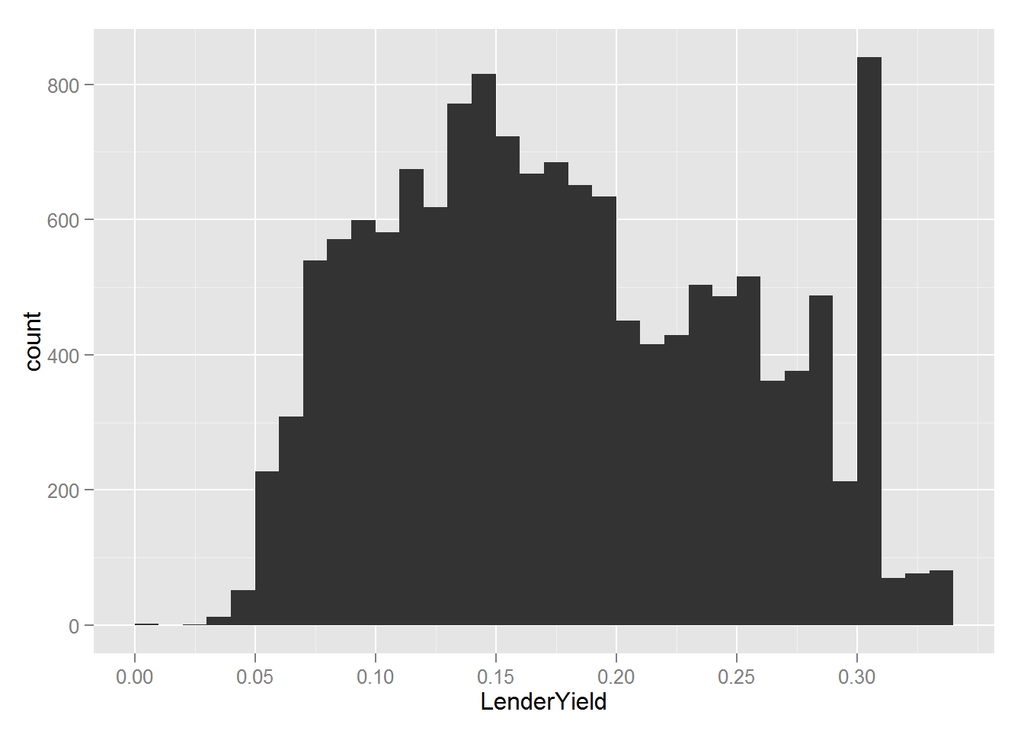

The distribution of Lender Yield is similar to the BorrowerRate distribution with similar characteristics

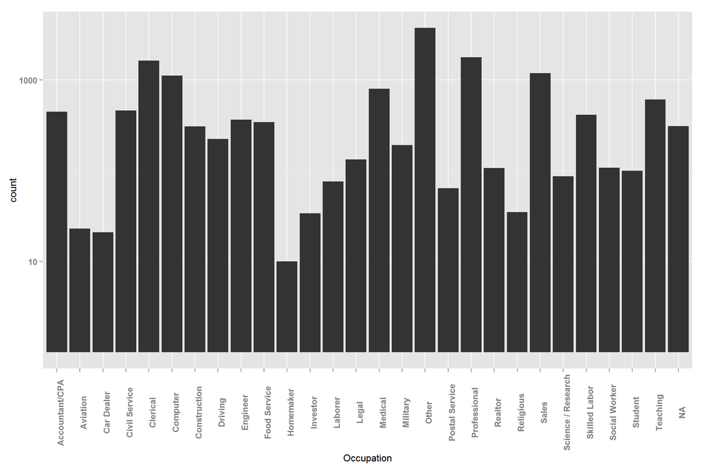

We have log transformed the Y axis because the maximum is few orders of magnitude greater than the minimum values

```
##                    Employed     Full-time Not available  Not employed
##             0         67322         26355          5347           835
##         Other     Part-time       Retired Self-employed          NA's
##          3806          1088           795          6134          2255
```

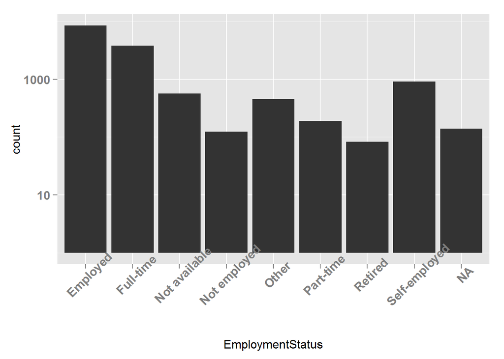

Most of the cases are Employed and Full-time. We have log transformed the Y axis because the maximum is few orders of magnitude greater than the minimum values

```
##    Min. 1st Qu.  Median    Mean 3rd Qu.    Max.
##    1000    4000    6500    8337   12000   35000
```

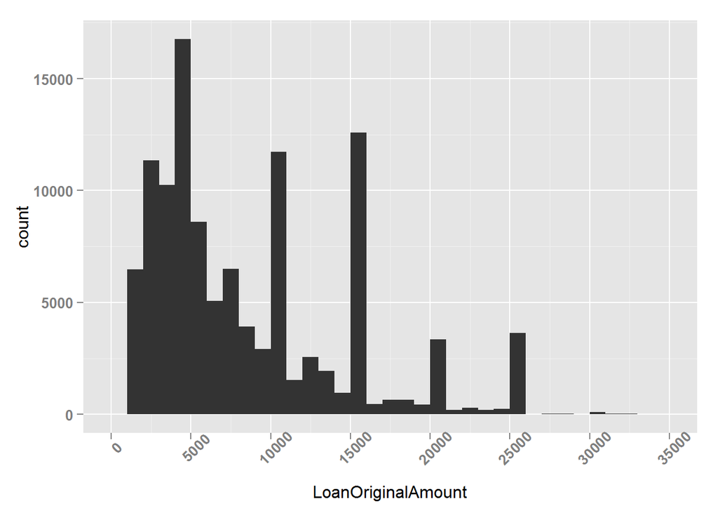

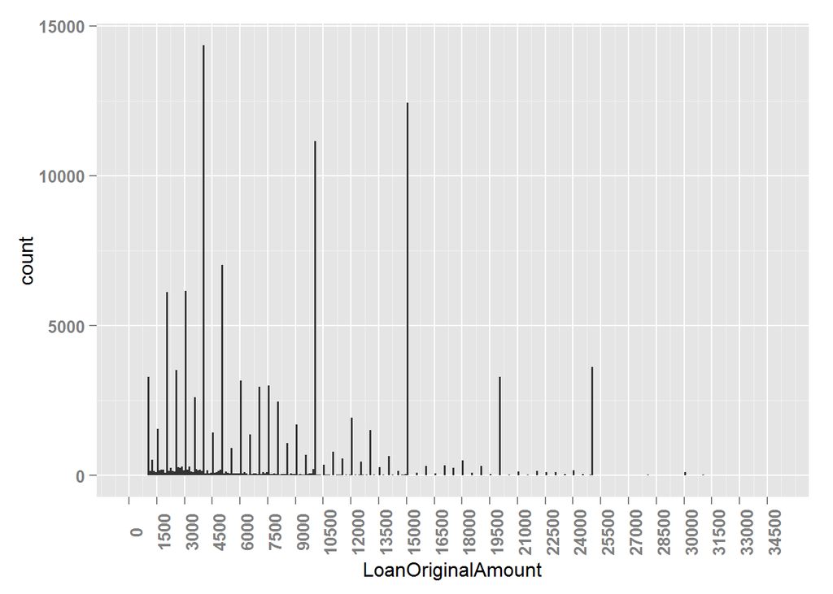

There are more cases between 1000 and 5000 gradually decreasing after 5000 as the loan amount increases. At 5000, 10000, 15000, 20000, 25000 the number of cases are more than the other nearby values

By decreasing the binwidth we see that there are more cases for 4000 followed by 15000 then followed by 10000 and then 5000. Most of the cases are in multiples of 1000. We also see that till 5000 there are few cases having values which are not in multiples of 1000, but after 15000 number of such cases are almost zero

```
##    Min. 1st Qu.  Median    Mean 3rd Qu.    Max.
##     0.0     0.0     0.0   855.7     0.0 25000.0
```

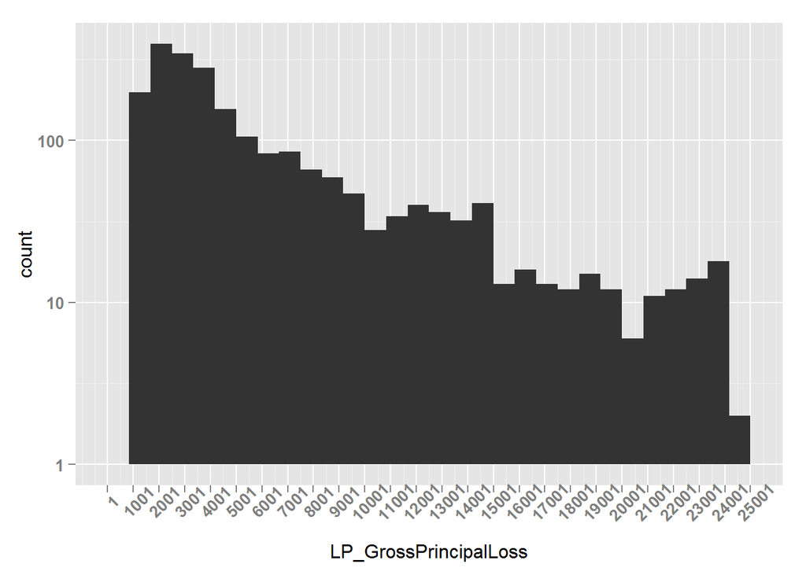

We have log transformed the Y axis because the maximum is few orders of magnitude greater than the minimum values

The Gross Principal Loss is zero for more than the first 3 quantiles. Hence we will ignores cases with Gross Principal Loss Zero. We see that there are more cases having Gross Principal Loss upto $ 4000 and there is a gradual decline in the cases for higher amounts. Also we see that after 15000 the number of cases are very few.

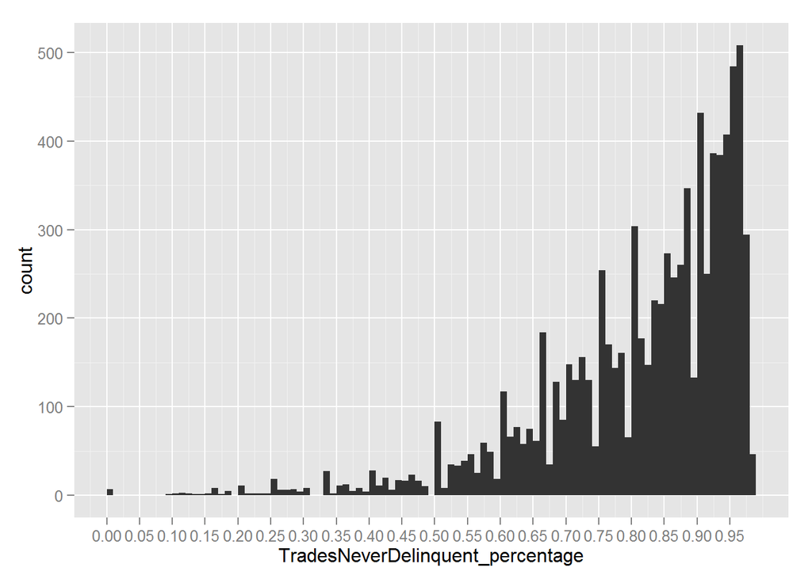

Almost 1/3rd of the cases never had delinquent trades. Hence we ignore cases which had delinquent trade less than one percent to get a more better understanding of the trades which were delinquent atleast 1 percent. Here we see a gradual increase from 0 to 0.99 peaking at around 0.95

```
##    Min. 1st Qu.  Median    Mean 3rd Qu.    Max.    NA's
##  0.0000  0.1300  0.2000  0.2619  0.2900 10.0100    1194
```

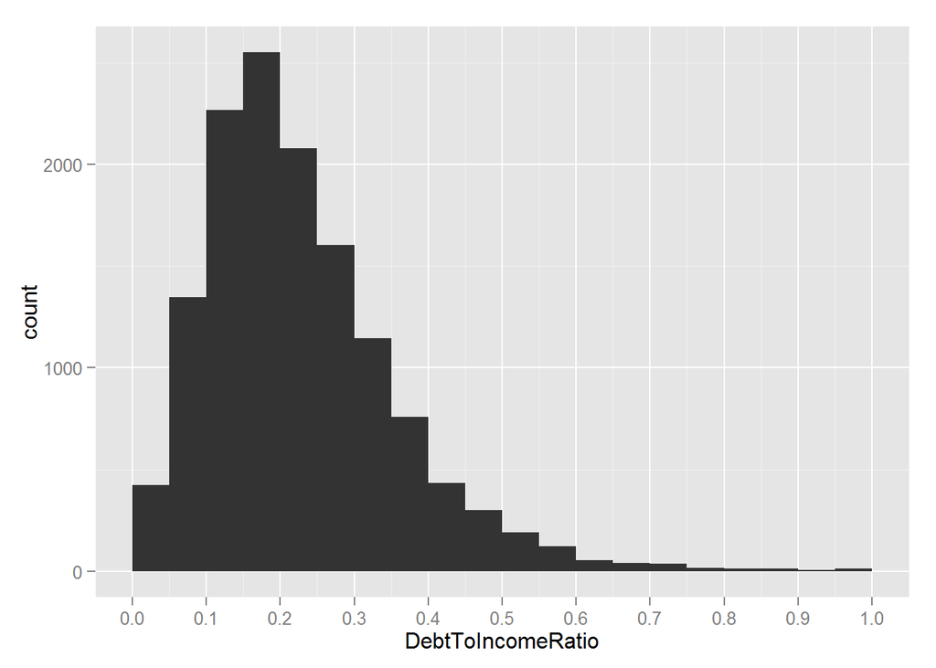

The Debt to income ratio increases steeply and peaks at 0.15 and then decreases gradually. The plot also shows that almost 50% of the population have 20% in Debt as compared to their income and 75% of the population have Debt of 29% or less as compared to their income

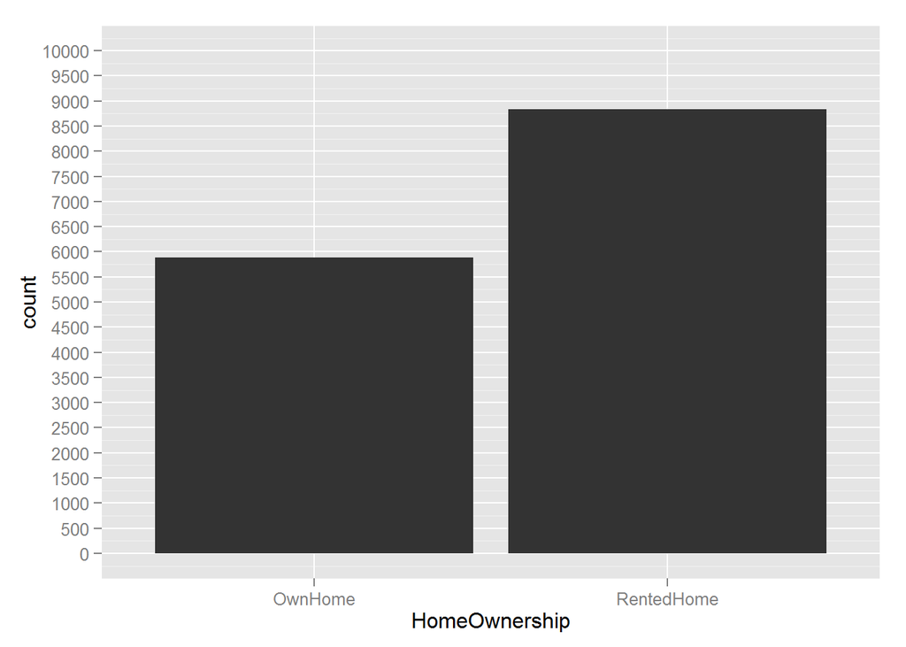

# Univariate Analysis

### What is the structure of your dataset?

The Prosper Loan Dataset has 113937 observations of 81 variables. We are focusing on the state of Califoria for our analysis

The state of Caliornia has 14717 observations

### What is/are the main feature(s) of interest in your dataset?

The main features that are of my interest in the dataset are  
Credit Grade  
ProsperRating_Alpha  
IsBorrowerHomeowner  
BorrowerRate  
LenderYield  
BorrowerState  
TradesNeverDelinquent_percentage  
LP_GrossPrincipalLoss  
LoanOriginalAmount

### What other features in the dataset do you think will help support your investigation into your feature(s) of interest?

The other features that will support the investigation are  
ClosedDate  
Term  
LoanStatus  
Occupation  
EmploymentStatus  
DebtToIncomeRatio  
IncomeRange

### Did you create any new variables from existing variables in the dataset?

I created 3 new variables CreditGrade_Derived, HomeOwnership and Occupation_Derived

CreditGrade_Derived - I found that for the Closed Loans the CreditGrade field is having values and for the Open Loans ProsperRating_Alpha has values. The CreditGrade_Derived is derived from CreditGrade and ProsperRating_Alpha fields

HomeOwnership - IsBorrowerHomeowner field is boolean field taking values as ‘True’ and ‘False’. In order to use it in the plots we have derived this new variable which is updated with ‘OwnHome’ if this field is ‘True’ and updated with ‘RentedHome’ if this field is ‘False’

Occupation_Derived - There are many Occupations in the dataset. In order to form our understanding around this attribute we have grouped the related occupations so that we have only a handful of distinct values to concentrate on. This in turn will help us understand the data better. we have derived this field from Occupation field by grouping similar Occupations under one head.

### Of the features you investigated, were there any unusual distributions? Did you perform any operations on the data to tidy, adjust, or change the form of the data? If so, why did you do this?

For the following features the maximum is a few orders of magnitude greater than the minimum values. Hence we log transformed the Y axis in order to depict the information in the chart more visible  
BorrowerState  
CreditGrade_Derived  
LoanStatus  
Occupation_Derived  
EmploymentStatus  
LP_GrossPrincipalLoss

The fields LP_GrossPrincipalLoss has zero for many cases and TradesNeverDelinquent_percentage has 100 for many cases. So, we have ignored these cases and have plotted the histogram for these fields to better understand their distribution

# Bivariate Plots Section

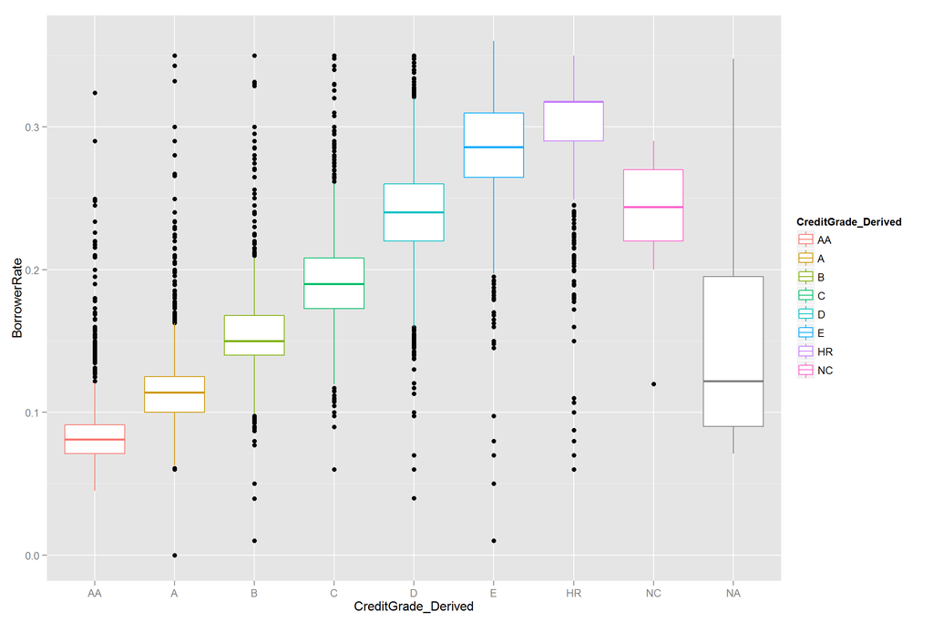

The first 3 quantiles of Borrower Rate for Credit grade AA is less than 10%. There are a few outliers which are greater than 10%. The median is gradually increasing from Credit Grade AA to HR. Credit Grades NC and NA are cases for which the Credit Grade is not defined and hence can be ignored. We also see that for HR the first quantile itself is just below the 30% mark. The median and third quantile are almost at the same level above 30% mark. The outliers for HR rating are data points below 25% mark

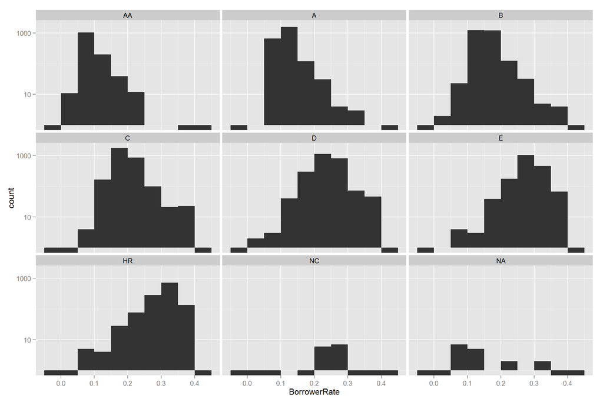

This plot supports the above box plot and shows that most of the AA cases are near the 10% mark and is gradually increasing as the credit rating decreases and for HR rating most of the cases are above the 30% mark

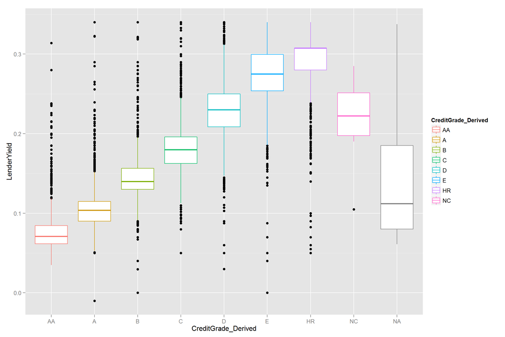

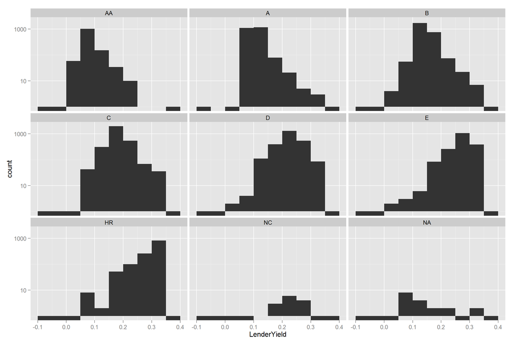

The plot for Lender Yield is similar to the Borrower rate. The lender Yield for AA rating is just below 10% mark for the first 3 quantiles. The median is gradually increasing as the Credit Grade decreases. For the HR rating the first quantile is below the 30% mark and the median and third quantile are just above the 30% mark and almost at the same level

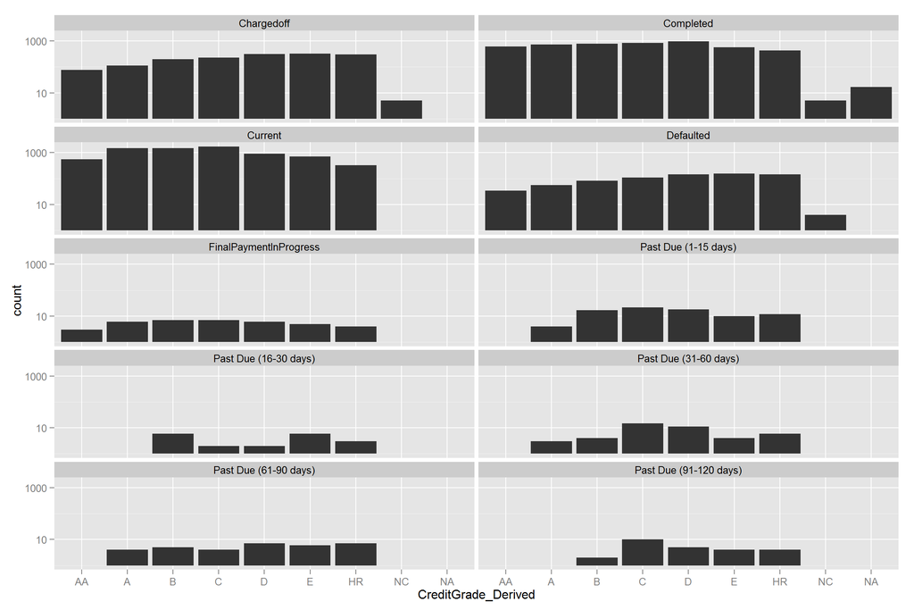

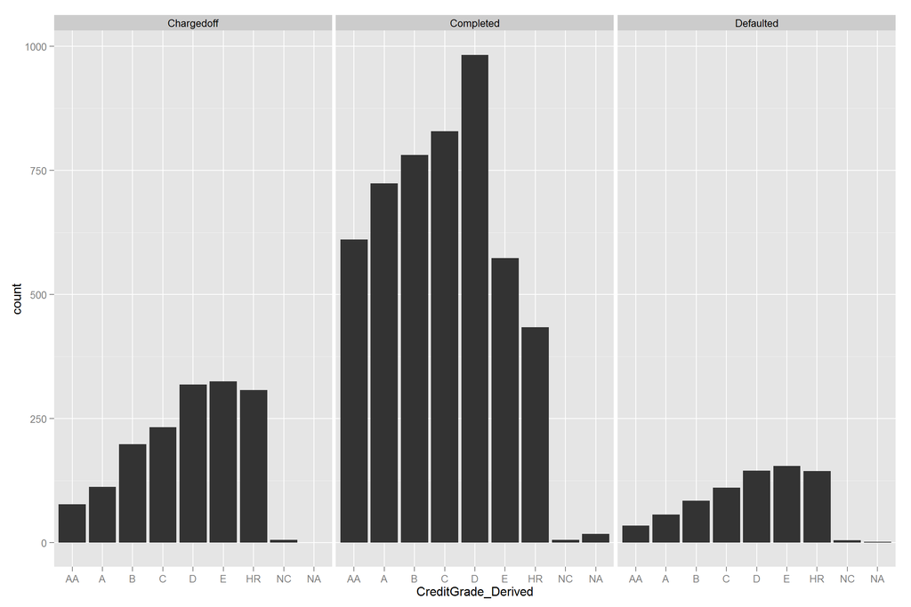

The first Plot is histogram of Credit Grade facet wrapped over the Loan Status. We have log transformed the Y axis as the number of cases in the current and the completed category outnumbers the other categories by a very huge margin. We have considered both in-progress Loans and Completed Loans. We see that most of the Loans are current followed by Completed and then the Charged off and then defaulted and then Loans in different Past due buckets. The Past due cases are very few.

The second Plot is histogram of Credit Grade facet wrapped over the Loan Status only for the Completed cases. We see that there is a significant number of cases which have been charged off and most of them are from D, E and HR Credit Grade. Similarly, there are many defaulted cases and most of the defaulted cases are also from the D, E and HR Credit Grade. The charged off cases and the Defaulted cases are increasing from AA to HR

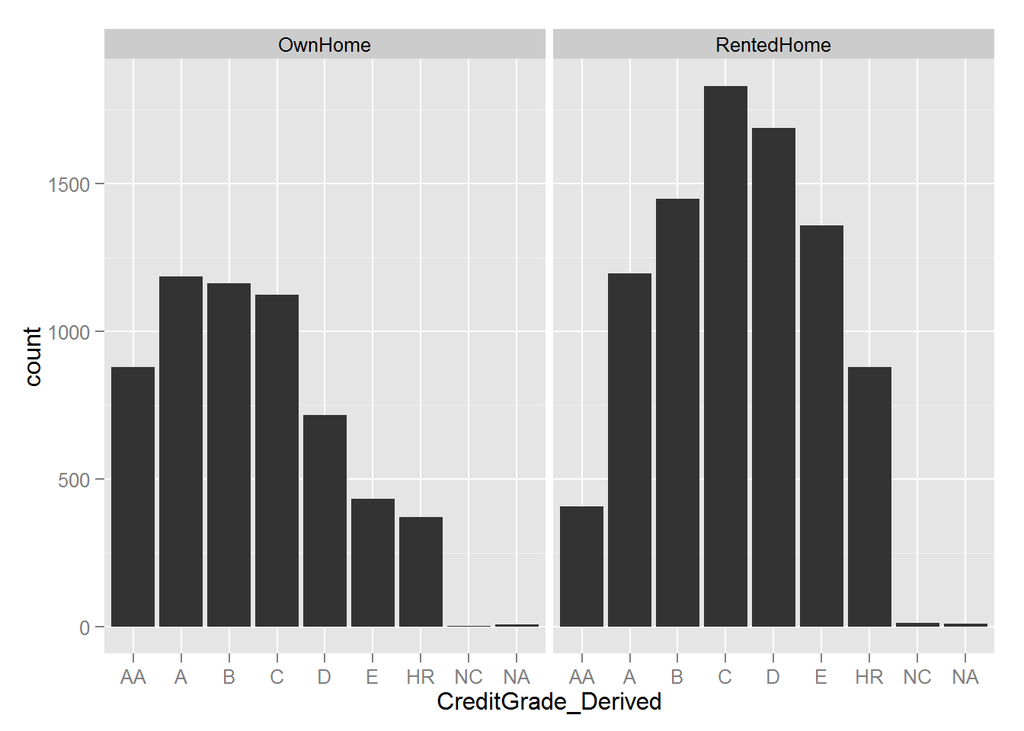

The number of cases are more for the higher Credit Grades (AA, A, B and C) for Owned Home cases as compared to the lower Credit Grades (D, E and HR) whereas for the Rented Home cases it is gradually increasing from AA to C and then gradually decreases from D to HR. Except for the Credit Grade AA and A there are more number of cases for Rented Home category as compared to Owned home category

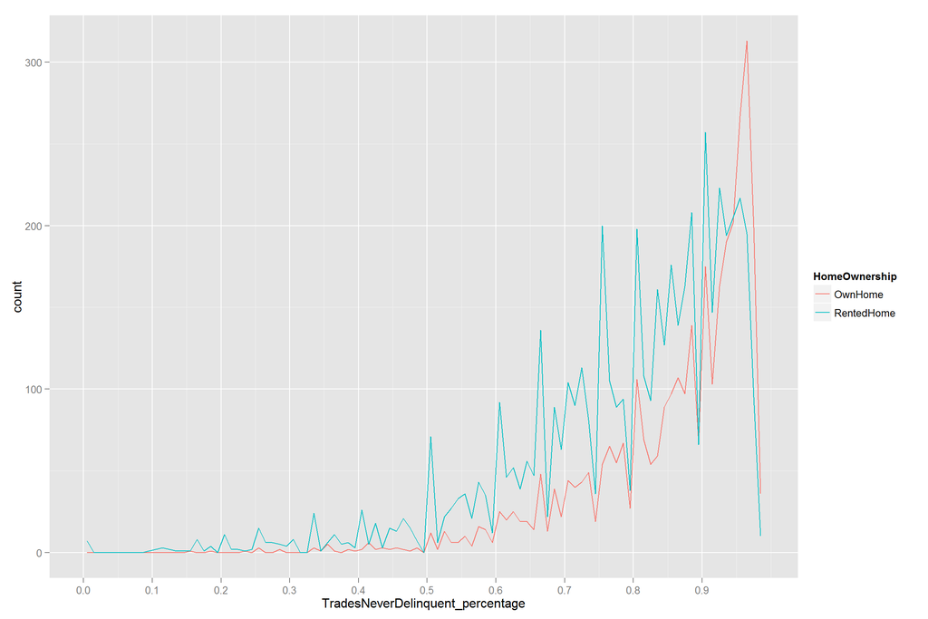

We see that more trades are delinquent for Rented Home Borrowers as compared to the Own Home Borrowers. Since most of the Trades are non delinquent, removing the data points for TradesNeverDelinquent_percentage of 1 and analyzing the rest of the data points we see that for most of the cases the Rented Home Borrowers have more delinquencies as compared to Own home Borrowers. The Own Home Borrowers have higher number only for a small range of 0.95 to 0.99

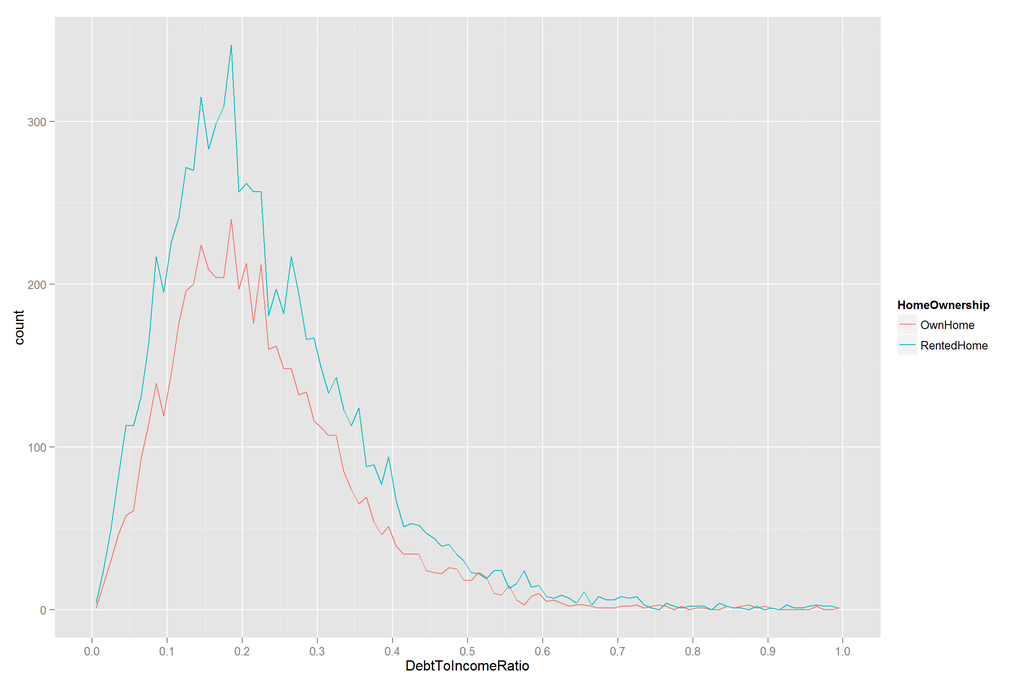

Though the lines are almost similar, it seems that Rented home borrowers have a better Debt to Income ratio than Own Home Borrowers as there are more rented home borrowers with the ratio less than 0.5 and after 0.5 both the lines are almost touching each other

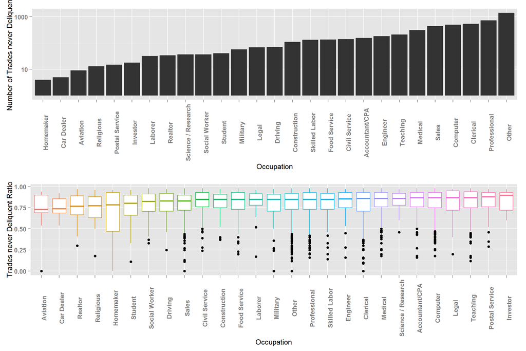

We are analyzing the Trade Deliquencies across different Occupations in this plot

We have log transformed the Y axis for the bar chart of Occupation for Trades Never Delinquent Percentage equal to 1 as there is a wide difference between the maximum and minimum Values

The Occupations “Aviation” and “Car Dealer” have more Trade Delinquencies as compared to other Trades with their mean around 25% (The mean of trades not Delinquent is around 75% for these 2 groups implying 25% Delinquency). For these 2 groups the number of Trades never Delinquent is also very low. Followed by these 2 groups are the groups “Realtor”, “Religious” and “Home Maker” which have higher Delinquency with mean around 20% and these groups also have very low number of Trades which were never Delinquent.

The Occupations “Other”, “Professional”, “Clerical”, “Computer” and “Sales” have more number of non Delinquent Trades as compared to other Occupations

```
##    Min. 1st Qu.  Median    Mean 3rd Qu.    Max.
##       0    3500    5250    6185    7583  618500
```

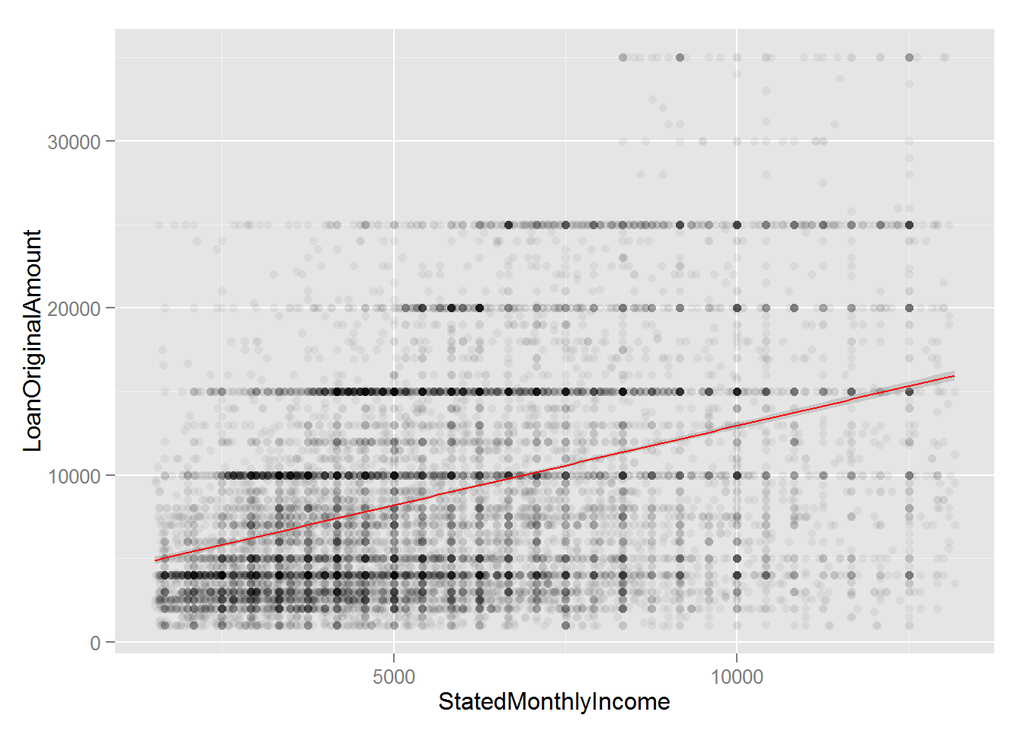

```
##
##  Pearson's product-moment correlation
##
## data:  pldca$StatedMonthlyIncome and pldca$LoanOriginalAmount
## t = 25.8685, df = 14715, p-value < 2.2e-16
## alternative hypothesis: true correlation is not equal to 0
## 95 percent confidence interval:
##  0.1930554 0.2239631
## sample estimates:
##       cor
## 0.2085613
```

Many people have not disclosed their income and some of the borrowers are retired or homemakers so we will ignore the lower 5% cases and there are very high income people so we will ignore the higher 5% cases for this plot. The correlation coefficient is 0.208 which suggests that the correlation is not meaningful. But, we see that the regression line is gradually increasing which is due to variation in the upper side of the Loan amount. The Loan amount for lower income group is more concentrated on the lower side of the regression line whereas for higher Income group the data is more dispersed and evenly distributed above and below the regression line. This might be because higher income group might be having Loan eligibility for higher amount whereas the eligibility for lower income group it might be less and the higher income group inspite being eligible for higher loan amounts many are applying for much less amount than their eligibility. Also, we see that certain loan amounts are more popular. The Loan amounts of 4000 and 5000 is more popular among low income groups. The loan amount of 10000 is popular among people having income above 2500. The loan amount of 15000 is popular among people having income above 4000. The loan amounts of 15000, 20000 and 25000 are more popular than other amounts among people having income above 10000

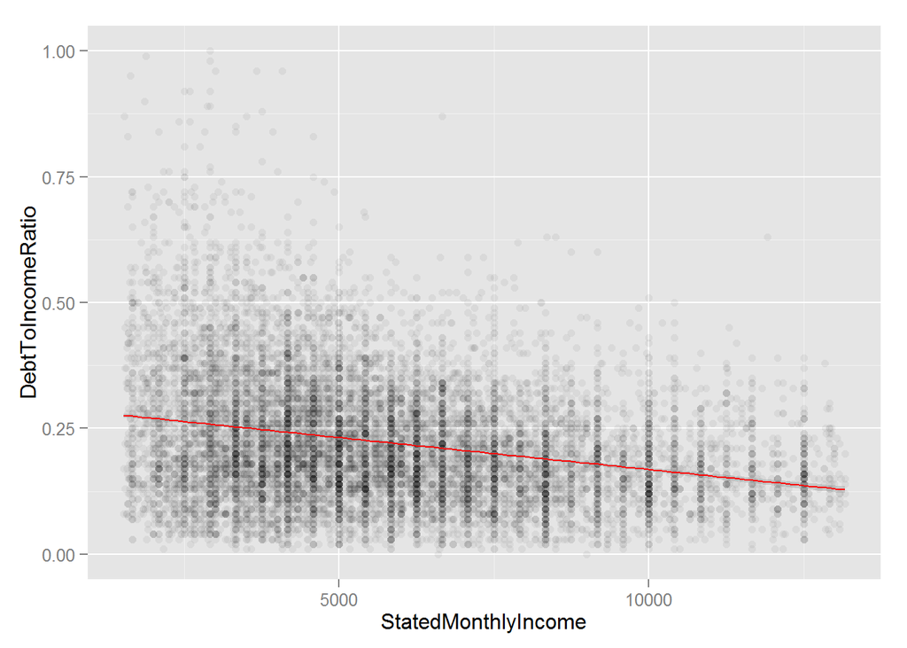

```
##
##  Pearson's product-moment correlation
##
## data:  pldca$StatedMonthlyIncome and pldca$DebtToIncomeRatio
## t = -14.8938, df = 13521, p-value < 2.2e-16
## alternative hypothesis: true correlation is not equal to 0
## 95 percent confidence interval:
##  -0.1435953 -0.1104301
## sample estimates:
##        cor
## -0.1270482
```

We will ignore the lower 5% cases and the higher 5% cases for this plot as well. The correlation coefficient is - 0.127 which suggests that the correlation is not meaningful. But, we see that the regression line is gradually decreasing which is because the 2 extremes are more wider for lower income group and are narrower for the higher income group and most people in the higher income group are below 0.25 whereas for the lower income group there are many cases between 0.25 and 0.5

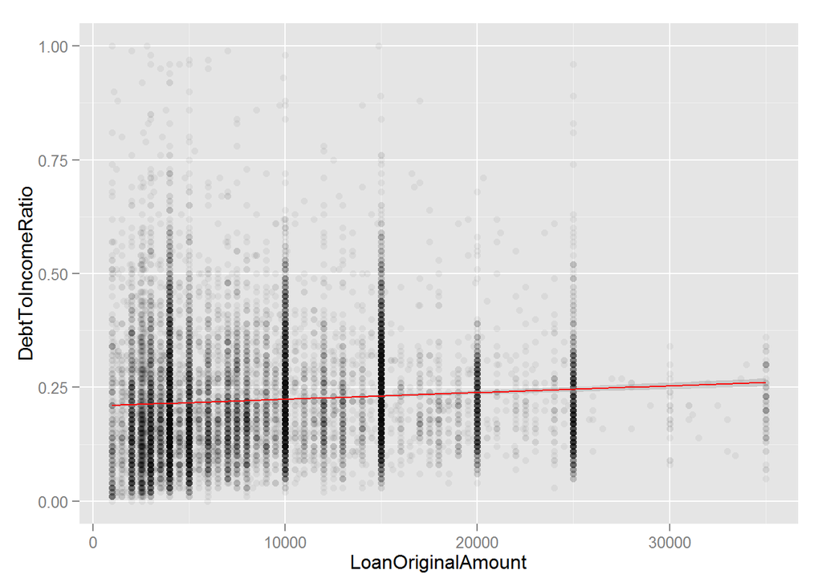

```
##
##  Pearson's product-moment correlation
##
## data:  pldca$LoanOriginalAmount and pldca$DebtToIncomeRatio
## t = 3.1724, df = 13521, p-value = 0.001515
## alternative hypothesis: true correlation is not equal to 0
## 95 percent confidence interval:
##  0.01042241 0.04410656
## sample estimates:
##        cor
## 0.02727222
```

The correlation coefficient is 0.027 which suggests that the correlation is not meaningful. The regression line is almost parallel to the x-axis which suggests that the average DebtToIncomeRatio across all Loan amounts is almost same at around 0.25

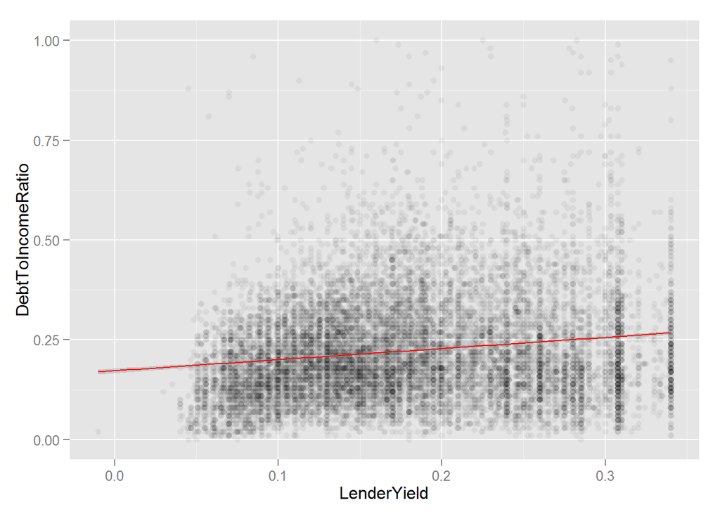

```
##
##  Pearson's product-moment correlation
##
## data:  pldca$LenderYield and pldca$DebtToIncomeRatio
## t = 6.3362, df = 13521, p-value = 2.429e-10
## alternative hypothesis: true correlation is not equal to 0
## 95 percent confidence interval:
##  0.03759025 0.07119970
## sample estimates:
##        cor
## 0.05441039
```

The correlation coefficient is 0.054 which suggests that the correlation is not meaningful. The regression line is gradually increasing. The DebtToIncomeRatio is more dispersed for higher LenderYield and the 2 extremes are more wider for higher LenderYield and is narrower for the lower LenderYield

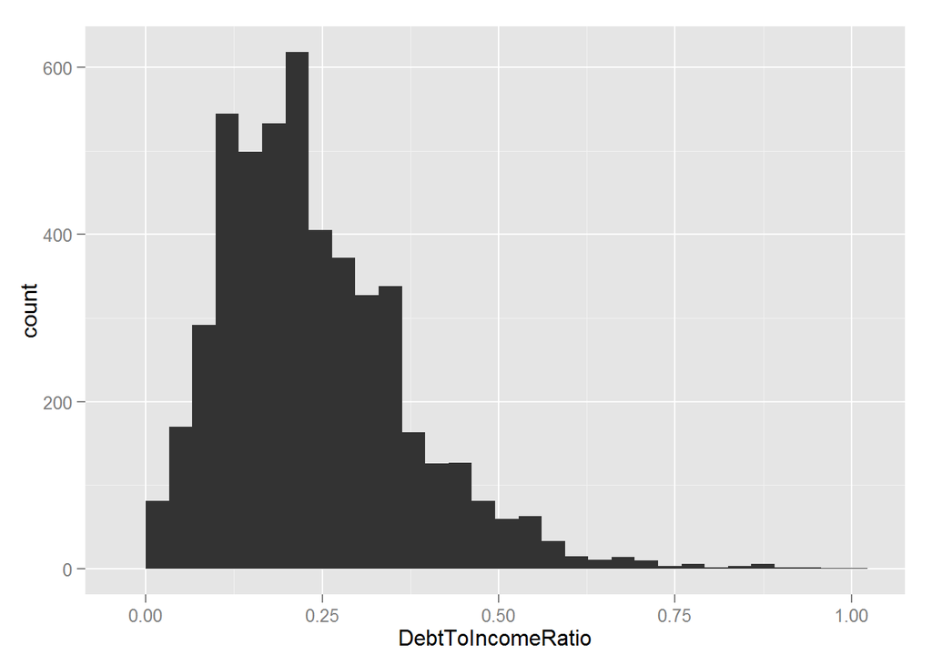

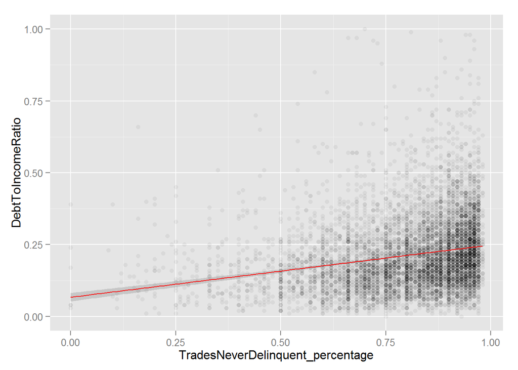

```
##
##  Pearson's product-moment correlation
##
## data:  pldca$TradesNeverDelinquent_percentage and pldca$DebtToIncomeRatio
## t = 5.7542, df = 12836, p-value = 8.902e-09
## alternative hypothesis: true correlation is not equal to 0
## 95 percent confidence interval:
##  0.03345487 0.06796276
## sample estimates:
##        cor
## 0.05072395
```

2 Plots have been plotted to understand the relation between the Debt to Income Ratio and Trades Never Delinquent Percentage

The first plot is a bar plot of Debt to Income Ratio for Trades which have never been Delinquent. Most of the cases are for Debt to Income Ratio less than 0.5. The number of cases gradually increases from 0 and peaks at around 0.25 and then gradually decreases